# Filtering and summarizing camera data for analysis of visit duration

This is an extra analysis added during peer review.

## Step 1: Get data

Have already filtered data for analysis in previous script, ‘02_filtering_summarizing_camera_data’.

Will do some additional filtering here to remove instances of a bird perching on the plant, which would generate extra long sighting (“visit”) durations.

Also, some camera sets had >1 plant species in the frame, but the sighting length is for ALL plant species combined. Will not analyze these sightings, because interpretation is a bit awkward; can not interpret results as time spent at each inflorescence of a given plant species. Also, if I keep these sightings, there would be a mismatch between sighting length (for >1 plant species) and the flowers covariate (counted for each plant species).

```r
#Get data
data_for_experiment <- read.csv("../../data/export/intermediate/Camera_data_filtered_for_experiment.csv")

# Get plant names
plant_names <- read.csv("../../data/import/data/Plant_codes_species_list.csv") %>%
  select(plant_species, plant_scientific_name) %>%
  filter(!is.na(plant_species) & plant_species != "") #Get rid of blank rows

#Source helper functions
source("../../code/helper_functions/Calculate_basic_summary_stats.R")
source("../../code/helper_functions/Summarize_camera_data.R")
source("../../code/helper_functions/Modeling_helper_functions.R")
source("../../code/helper_functions/Plotting_helper_functions.R")

#Filter out camera sets with >1 plant species
#Filter out instances of bird perching in frame, based on notes column
#Filter out videos without flower counts; I need to include flowers as a covariate, because expect longer sightings when there are more flowers to visit
single_species_camera_sets <- data_for_experiment %>%
  distinct(year, patch, camera_num, plant_species) %>%
  group_by(year, patch, camera_num) %>%
  summarise(num_species = n()) %>%
  filter(num_species == 1)

data_for_sighting_duration <- data_for_experiment %>%
  left_join(single_species_camera_sets) %>%
  filter(num_species == 1) %>%
  select(-num_species, -X) %>%
  filter(!grepl("perch", sighting_notes, ignore.case = TRUE)) %>%
  filter(sightings_yes_or_no == "Y") %>%
  filter(visit_type != "none") %>%
  filter(!is.na(flowers_camera_video))
```

## Step 2: Explore data

What is average sighting length?

```r
#Time per sighting (in seconds) - across all bird and plant species
data_for_sighting_duration %>%
  calculate_basic_summary_stats(variable = sighting_length)
```

```
##   min max     mean       sd median    n
## 1   1  70 7.989921 7.218432      6 5159
```

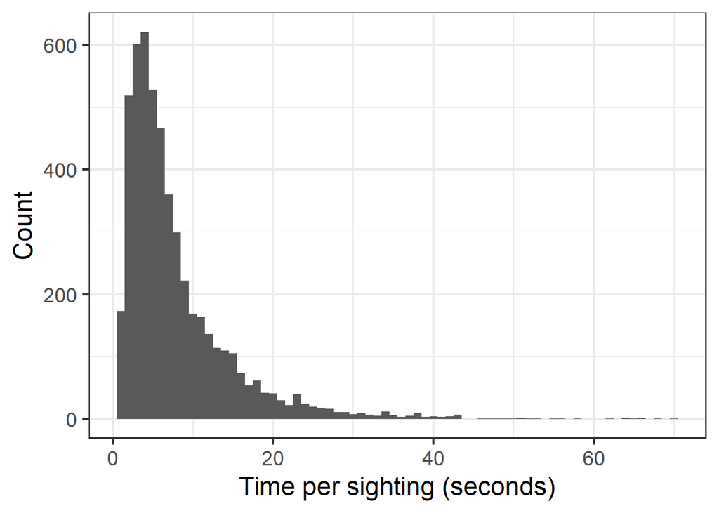

```r
#PLOT: Time per sighting (in seconds) - across all bird and plant species
data_for_sighting_duration %>%
  ggplot(aes(x = sighting_length), data = .) +
    geom_histogram(binwidth = 1, center = 0) +
    theme_bw(base_size = 18) +
    labs(x = "Time per sighting (seconds)", y = "Count")
```

## Step 3: Summarize data

These are the same summaries for visitation rate analyses, *except* that I am using a dataset that has sightings with perching filtered out.

```r
sighting_durations_all_spp = calculate_sighting_rates(data = data_for_sighting_duration, level_org = "plant_species", level_time = "exp_phase", level_bird = "camera_spp_combined", sightings = "with_visit", include_unknown_spp = FALSE) %>%
  mutate(bird_group = "all_spp") #Replace "camera_spp_combined" with "all_spp"

sighting_durations_greh_visa = calculate_sighting_rates(data = data_for_sighting_duration, level_org = "plant_species", level_time = "exp_phase", level_bird = list(greh_visa = c("GREH", "VISA")), sightings = "with_visit", include_unknown_spp = FALSE)

#Combine various summaries
sighting_durations <- sighting_durations_all_spp %>%
  bind_rows(sighting_durations_greh_visa) %>%
  select(bird_group, everything()) %>%
  mutate(time_per_sighting = sightings_time/sightings) #Time is in seconds
```

Not all plants have sightings pre and post; can only analyze changes in sighting duration if both experimental periods have sightings, so need to remove plant species that do not have sightings pre and post

```r
#Identify plant species that have sightings during both experimental periods
species_pre_and_post <- sighting_durations %>%
  filter(!is.na(sightings_time)) %>%
  distinct(bird_group, year, patch, control_treatment, plant_species, exp_phase) %>%
  group_by(bird_group, year, patch, control_treatment, plant_species) %>%
  summarise(num_periods = n()) %>%
  ungroup() %>%
  filter(num_periods == 2)

#Filter out species that did not have sightings during both experimental periods
#Add plant species scientific names
sighting_durations_for_analysis <- sighting_durations %>%
  left_join(species_pre_and_post) %>%
  filter(num_periods == 2) %>%
  select(-num_periods, -hours, -sightings_per_hour) %>%
  left_join(plant_names)

#Check: are there any NAs in the sighting_duration column?
check01 <- sighting_durations_for_analysis %>%
  filter(is.na(sightings_time))
```

## Step 4: Export data

```r
write.csv(sighting_durations_for_analysis, "../../data/export/for_analysis/Camera_visit_durations.csv", row.names = FALSE)
```